# k-Means

Afaf MS

2026-10-27

```r
Pharmaceuticals <- read.csv("Pharmaceuticals.csv")
head(Pharmaceuticals)
```

```
##   Symbol                Name Market_Cap Beta PE_Ratio  ROE  ROA Asset_Turnover
## 1    ABT Abbott Laboratories      68.44 0.32     24.7 26.4 11.8            0.7
## 2    AGN      Allergan, Inc.       7.58 0.41     82.5 12.9  5.5            0.9
## 3    AHM        Amersham plc       6.30 0.46     20.7 14.9  7.8            0.9
## 4    AZN     AstraZeneca PLC      67.63 0.52     21.5 27.4 15.4            0.9
## 5    AVE             Aventis      47.16 0.32     20.1 21.8  7.5            0.6
## 6    BAY            Bayer AG      16.90 1.11     27.9  3.9  1.4            0.6
##   Leverage Rev_Growth Net_Profit_Margin Median_Recommendation Location Exchange
## 1     0.42       7.54              16.1          Moderate Buy       US     NYSE
## 2     0.60       9.16               5.5          Moderate Buy   CANADA     NYSE
## 3     0.27       7.05              11.2            Strong Buy       UK     NYSE
## 4     0.00      15.00              18.0         Moderate Sell       UK     NYSE
## 5     0.34      26.81              12.9          Moderate Buy   FRANCE     NYSE
## 6     0.00      -3.17               2.6                  Hold  GERMANY     NYSE
```

```r
names(Pharmaceuticals)
```

```
##  [1] "Symbol"                "Name"                  "Market_Cap"
##  [4] "Beta"                  "PE_Ratio"              "ROE"
##  [7] "ROA"                   "Asset_Turnover"        "Leverage"
## [10] "Rev_Growth"            "Net_Profit_Margin"     "Median_Recommendation"
## [13] "Location"              "Exchange"
```

```r
dim(Pharmaceuticals)
```

```
## [1] 21 14
```

```r
financial.df <- Pharmaceuticals[, c(
  "Market_Cap",
  "Beta",
  "PE_Ratio",
  "ROE",
  "ROA",
  "Asset_Turnover",
  "Leverage",
  "Rev_Growth",
  "Net_Profit_Margin"
)]
dim(financial.df)
```

```
## [1] 21  9
```

```r
financial.scaled <- scale(financial.df)
head(financial.scaled)
```

```
##      Market_Cap        Beta    PE_Ratio         ROE        ROA Asset_Turnover
## [1,]  0.1840960 -0.80125356 -0.04671323  0.04009035  0.2416121      0.0000000
## [2,] -0.8544181 -0.45070513  3.49706911 -0.85483986 -0.9422871      0.9225312
## [3,] -0.8762600 -0.25595600 -0.29195768 -0.72225761 -0.5100700      0.9225312
## [4,]  0.1702742 -0.02225704 -0.24290879  0.10638147  0.9181259      0.9225312
## [5,] -0.1790256 -0.80125356 -0.32874435 -0.26484883 -0.5664461     -0.4612656
## [6,] -0.6953818  2.27578267  0.14948233 -1.45146000 -1.7127612     -0.4612656
##        Leverage Rev_Growth Net_Profit_Margin
## [1,] -0.2120979 -0.5277675        0.06168225
## [2,]  0.0182843 -0.3811391       -1.55366706
## [3,] -0.4040831 -0.5721181       -0.68503583
## [4,] -0.7496565  0.1474473        0.35122600
## [5,] -0.3144900  1.2163867       -0.42597037
## [6,] -0.7496565 -1.4971443       -1.99560225
```

```r
apply(financial.scaled, 2, mean)
```

```
##        Market_Cap              Beta          PE_Ratio               ROE
##     -4.843286e-17      1.627439e-16     -2.148785e-17      3.335212e-17
##               ROA    Asset_Turnover          Leverage        Rev_Growth
##      3.700743e-17      2.008923e-16     -6.821439e-17     -7.171739e-17
## Net_Profit_Margin
##      1.173003e-16
```

```r
apply(financial.scaled, 2, sd)
```

```
##        Market_Cap              Beta          PE_Ratio               ROE
##                 1                 1                 1                 1
##               ROA    Asset_Turnover          Leverage        Rev_Growth
##                 1                 1                 1                 1
## Net_Profit_Margin
##                 1
```

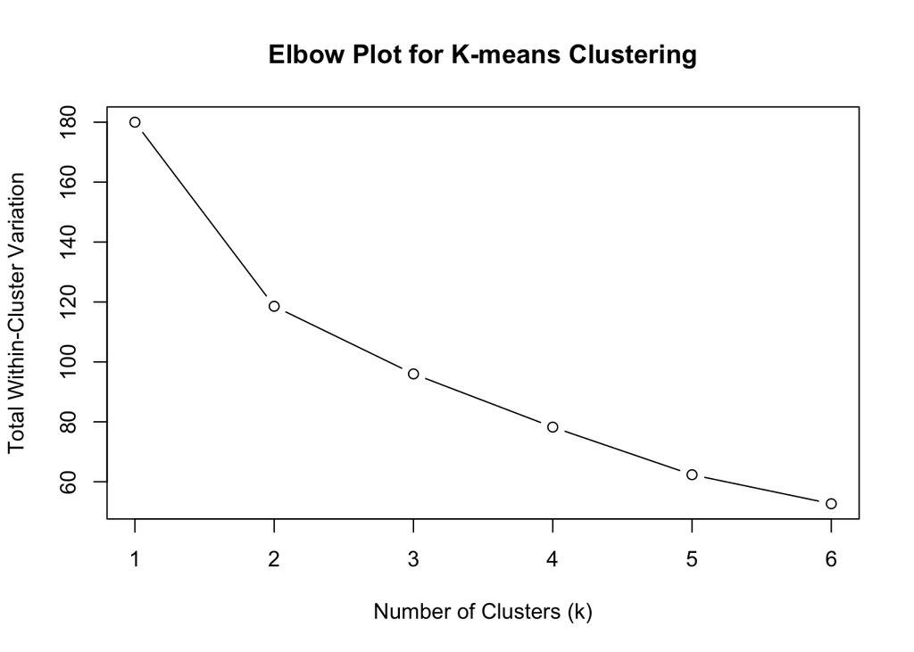

```r
set.seed(1)
wss <- numeric(6)
for (k in 1:6) {
  model <- kmeans(financial.scaled, centers = k, nstart = 10)
  wss[k] <- model$tot.withinss
}
plot(1:6, wss,
     type = "b",
     xlab = "Number of Clusters (k)",
     ylab = "Total Within-Cluster Variation",
     main = "Elbow Plot for K-means Clustering")
```

```r
set.seed(1)
three.clusters <- kmeans(financial.scaled, centers = 3, nstart = 10 )
three.clusters$cluster
```

```
##  [1] 2 1 1 2 3 1 2 3 3 2 2 3 2 3 2 2 2 1 2 3 2
```

```r
table(three.clusters$cluster)
```

```
##
##  1  2  3
##  4 11  6
```

```r
aggregate(as.data.frame(financial.scaled),
          by = list(Cluster = three.clusters$cluster),
          FUN = mean)
```

```
##   Cluster Market_Cap       Beta   PE_Ratio        ROE        ROA Asset_Turnover
## 1       1 -0.6125361  0.2698666  1.3143935 -0.9609057 -1.0174553      0.2306328
## 2       2  0.6733825 -0.3586419 -0.2763512  0.6565978  0.8344159      0.4612656
## 3       3 -0.8261772  0.4775991 -0.3696184 -0.5631589 -0.8514589     -0.9994088
##     Leverage Rev_Growth Net_Profit_Margin
## 1 -0.3592866 -0.5757385        -1.3784169
## 2 -0.3331068 -0.2902163         0.6823310
## 3  0.8502201  0.9158889        -0.3319956
```

```r
cluster.details <- data.frame(
  Cluster = three.clusters$cluster,
  Median_Recommendation = Pharmaceuticals$Median_Recommendation,
  Location = Pharmaceuticals$Location,
  Exchange = Pharmaceuticals$Exchange
)
cluster.details
```

```
##    Cluster Median_Recommendation    Location Exchange
## 1        2          Moderate Buy          US     NYSE
## 2        1          Moderate Buy      CANADA     NYSE
## 3        1            Strong Buy          UK     NYSE
## 4        2         Moderate Sell          UK     NYSE
## 5        3          Moderate Buy      FRANCE     NYSE
## 6        1                  Hold     GERMANY     NYSE
## 7        2         Moderate Sell          US     NYSE
## 8        3          Moderate Buy          US   NASDAQ
## 9        3         Moderate Sell     IRELAND     NYSE
## 10       2                  Hold          US     NYSE
## 11       2                  Hold          UK     NYSE
## 12       3                  Hold          US     AMEX
## 13       2          Moderate Buy          US     NYSE
## 14       3          Moderate Buy          US     NYSE
## 15       2                  Hold          US     NYSE
## 16       2                  Hold SWITZERLAND     NYSE
## 17       2          Moderate Buy          US     NYSE
## 18       1                  Hold          US     NYSE
## 19       2                  Hold          US     NYSE
## 20       3         Moderate Sell          US     NYSE
## 21       2                  Hold          US     NYSE
```

```r
table(cluster.details$Cluster, cluster.details$Median_Recommendation)
```

```
##
##     Hold Moderate Buy Moderate Sell Strong Buy
##   1    2            1             0          1
##   2    6            3             2          0
##   3    1            3             2          0
```

```r
table(cluster.details$Cluster, cluster.details$Location)
```

```
##
##     CANADA FRANCE GERMANY IRELAND SWITZERLAND UK US
##   1      1      0       1       0           0  1  1
##   2      0      0       0       0           1  2  8
##   3      0      1       0       1           0  0  4
```

```r
table(cluster.details$Cluster, cluster.details$Exchange)
```

```
##
##     AMEX NASDAQ NYSE
##   1    0      0    4
##   2    0      0   11
##   3    1      1    4
```

```r
knitr::opts_chunk$set(echo = TRUE)
```

Question a: I used k-means clustering to group the 21 pharmaceutical firms based on the nine numerical variables.

After selecting the nine numerical variables, I standardized them using scale(). Some variables, such as Market_Cap, have much larger numerical values than others. Without standardization, clustering could be dominated by variables with larger numerical scales. Standardization lets variables contribute on comparable scales so the clustering reflects their relative patterns rather than being skewed by their large numbers.

Question b: The standardized variables helped me interpret the three clusters. Cluster 1 shows a PE_Ratio well above average, while ROE, ROA, and net profit margin are well below average.

Cluster 2 shows above-average values for market capitalization, ROE, ROA, and net profit margin. These values distinguish Cluster 2 from Clusters 1 and 3, where these values are below average. Cluster 3 differs in revenue growth and leverage, which are above average, while they are below average in Clusters 1 and 2. At the same time, Cluster 3 has the lowest average asset turnover of the three clusters. Overall, net profit margin, ROA, and PE_Ratio are major distinguishing characteristics of the three clusters. So these three variables help explain the differences between the clusters, but they do not fully describe the financial profiles of the companies, since all nine numerical variables were used to form the clusters.

Question c: Variables 10 to 12 show a pattern, with mixed recommendations within each cluster. Cluster 1 is mixed, with two companies rated Hold. However, it is the only cluster with 1 strong buy recommendation. The cluster is also spread across four countries, and all are listed on the NYSE. Cluster 2 has the most firms rated Hold; most are based in the United States (8 out of 11), and all are listed on the NYSE. Finally, Cluster 3 has the most firms rated Moderate Buy, mostly based in the US (4 out of 6), and it is the only cluster that includes all stock exchanges.

Question d: While the names of the groups were primarily based on variables 1-9, they also took into account variables 10-12 from question c.

Cluster 1: Low Profitability, Highest PE_Ratio

Cluster 2: High Profitability, Larger Market Capitalization

Cluster 3: Highest Leverage and Revenue Growth, Lowest Asset Turnover